# Questionnaire Report for San Francisco Bay herring

(MERA version 5.4.3)

Brett van Poorten (brett.vanpoorten@gmail.com)

2019-11-26

# About this document

This is a prototype of an automatic report that documents how the user specified the operating model and their various justifications.

# Introduction

1. Describe the history and current status of the fishery, including fleets, sectors, vessel types and practices/gear by vessel type, landing ports, economics/markets, whether targeted/bycatch, other stocks caught in the fishery. The fishery is composed of herring eggs on kelp (HEOK - kelp placed in spawning areas and kelp/roe sold together), sac roe and live herring (both gill net). Recent creation of a local market has helped bolster the live fishery; the roe fishery began in earnest in 1972 when Japan began imports. “Recreational fishers typically use cast-nets to capture herring as they move inshore to spawn around pier pilings and jetties. Herring are typically used for human food or bait for other recreationally caught sport fish.” (http://opc.ca.gov/webmaster/ftp/project_pages/Rapid%20Assessments/Pacific%20Herring.pdf) Bycatch: “The gill net gear specified in regulations specifically targets Pacific herring based on a minimum mesh size and maximum overall net length. Based on the DFW commercial sampling data and staff observations, there is very little incidental take of non-target species. By-catch is typically limited to Jacksmelt (Atherinops californiensis) and sardines (Sardinops sagax); however, these species do not frequent areas targeted by the commercial herring fleet during the winter months and incidence as by-catch is minimal.” (http://opc.ca.gov/webmaster/ftp/project_pages/Rapid%20Assessments/Pacific%20Herring.pdf)

"Historical Fisheries

Herring fishing in California dates from at least the mid 1800’s. Catch records are not well documented prior to 1916, but annual catches were low with most of the fish sold fresh. Small amounts also were salted or pickled for human consumption. Harvesting occurred near the populated areas of Humboldt Bay, Bodega Bay, Tomales Bay, San Francisco Bay, Monterey Bay, and San Diego Bay. From 1916–1919 herring were canned or reduced into oil and meal (Scofield 1918). In 1918 the catch reached 8,000,000 lb (3,629 mt), mostly from Tomales Bay (Table 1). The Reduction Act of 1919 prohibited the reduction of whole herring into fish meal. This action ended the largest component of the fishery, although a small fishery for human consumption continued. Annual landings remained low until the late 1940’s when processors began to can herring as a replacement for sardines because that fishery was declining (Scofield 1952). This product was not well accepted by the public and by 1954 landings dropped to less than 1 million lb (454 mt) (Table 1). The fishery for human consumption (fresh and pickled herring) and bait has continued and today composes a minor part of the catch. Herring Eggs on Seaweed Fishery

In 1965 a new use for California herring products developed when Japan began importing herring roe on seaweed, “Kazunoko Kombu”, which is considered a delicacy. The Fish and Game Commission accepted separate sealed bids for the right to harvest herring eggs on seaweed in Tomales and San Francisco Bays. The highest bidder for each bay was awarded the opportunity to take 5 tons (4.5 mt) of eggs on seaweed. The amount of the bid was a royalty per ton paid to the Department after harvesting took place. The quota included the total weight of the seaweed with eggs attached. Herring eggs on Gracilaria spp. and Laminaria sp. are preferred and harvesting was done by divers. This fishery expanded to San Francisco Bay in 1966. The 5-ton quota has never been reached in either bay, but this continues to be a viable fishery with harvests every year since 1965 (Table 2)."(https://oac.cdlib.org/view?docId=kt3199n5xp&brand=oac4&doc.view=entire_text)

2. Describe the stock’s ecosystem functions, dependencies, and habitat types. “While in the ocean, adult herring feed on macroplankton such as copepods and euphausiids. Larval and juvenile herring are believed to feed on molluscan larvae and other zooplankton while in bays and estuaries. Herring are a forage species for a diverse group of marine fishes, birds, and mammals. Spawning events in particular provide an opportunity for feeding. As herring move into shallow water to spawn, a feeding frenzy may commence which can last for several days. Gulls, cormorants, pelicans and other marine birds; California and Stellar sea lions, harbor seals, invertebrates and a variety of fishes (including sturgeon in San Francisco Bay) feast on adult herring and embryos.” (http://opc.ca.gov/webmaster/ftp/project_pages/Rapid%20Assessments/Pacific%20Herring.pdf)
3. Provide all relevant reference materials, such as assessments, research, and other analysis.

Pacific Herring Rapid Assessment.pdf (also http://opc.ca.gov/webmaster/ftp/project_pages/Rapid%20Assessments/Pacific%20Herring.pdf) Scientific review of the draft Fishery Management Plan for Pacific herring (Clupea pallasii): (Herring Peer Review.pdf) Monterey Bay Aquarium Seafood Watch evaluation of the bottom gill net fishery (Seafood Watch Herring-Pacific-California.pdf) Pacific Herring Commercial Fishing Regulations (https://nrm.dfg.ca.gov/FileHandler.ashx?DocumentID=148632&inline) Status of The Pacific Herring, Clupea Harengus Pallasii, Resource In California 1972 to 1980 (https://oac.cdlib.org/view?docId=kt3199n5xp&brand=oac4&doc.view=entire_text)

# Fishery Characteristics

## Longevity

| Answered |
| --- |
| Very short-lived (5 < maximum age < 7) |
| Short-lived (7 < maximum age < 10) |
| Moderate life span (10 < maximum age < 20) |
| Moderately long-lived (20 < maximum age < 40) |
| Long-lived (40 < maximum age < 80) |
| Very long-lived (80 < maximum age < 160) |

| Justification |
| --- |
| “California herring can live to 9 years old and reach a maximum length of about 10 in (25 cm). However, it is extremely rare to find fish that are older than 7 years of age.” (Rapid Assessment Pacific… |

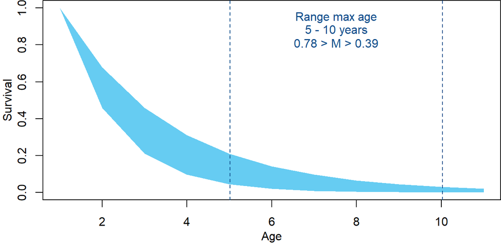

## Stock depletion

| Answered |
| --- |
| Crashed (D < 0.05) |
| Very depleted (0.05 < D < 0.1) |
| Depleted (0.1 < D < 0.15) |
| Moderately depleted (0.15 < D < 0.3) |
| Healthy (0.3 < D < 0.5) |
| Underexploited (0.5 < D) |

[output not shown]

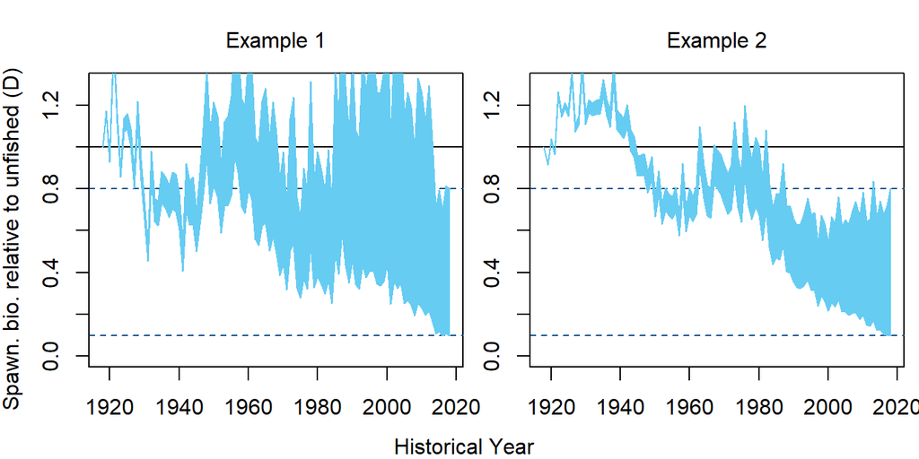

## Resilence

| Answered |
| --- |
| Not resilient (steepness < 0.3) |
| Low resilience (0.3 < steepness < 0.5) |
| Moderate resilence (0.5 < steepness < 0.7) |
| Resilient (0.7 < steepness < 0.9) |
| Very Resilient (0.9 < steepness) |

Justification

Early fishng history (<1916) unknown.  
“In recent years a decline in the price of sac-roe has led to a decline in effort. Effort has remained relatively stable over the past five years (Ryan Bartling, personal comm., 2013). Historically there were as many as 400 permits issued to approximately 100 boats, but in recent years this has dropped to approximately 180 permits issued each year to 25-35 vessels (Ryan Bartling, personal comm., 2013; CDFW Commercial License Data 2000-20121). Although herring sac-roe permits are still issued for San Francisco Bay, Humboldt Bay, Tomales Bay, and Crescent City Harbor, the sac-roe fishing effort has only occurred in San Francisco Bay in recent years. This is due to decreased product demand and lower price, which makes fishing effort in the other bays less economically viable (Ryan Bartling, personal comm., 2013). Historically San Francisco Bay has accounted for over 90% of the state landings, even when other bays were actively fished. Total sac-roe landings and quota for San Francisco Bay are in Figure 1.  
The other two components of the fishery, the fresh fish fishery and HEOK, are much smaller and receive a minor portion of the annual quota. Currently, the fresh fish fishery season is open for a brief period before the sac-roe fishery opens and for a few of weeks after it closes. The HEOK fishery operates only in San Francisco Bay through the winter months. In general the fresh fish fishery has little to no effort. During the 2012-2013 herring fishing season no fresh fish were landed under this fishery quota (20 tons). The HEOK fishery is highly variable due to a variety  
of reasons (Ryan Bartling personal comm., 2013). The fishery can receive a much higher price per pound than the sac roe fishery, but is a much riskier investment since there is the possibility of not landing any herring roe. This fishery has a 10 permit limit and vessels in the gillnet fishery have the option to convert their sac-roe permits to a HEOK permit annually. Figure 2 shows landings data for the HEOK fishery. During the 2012-13 season, the fishery landed close to its entire quota of 176 tons (Ryan Bartling personal comm., 2013).” (Pacific Herring Rapid Assessment.pdf)

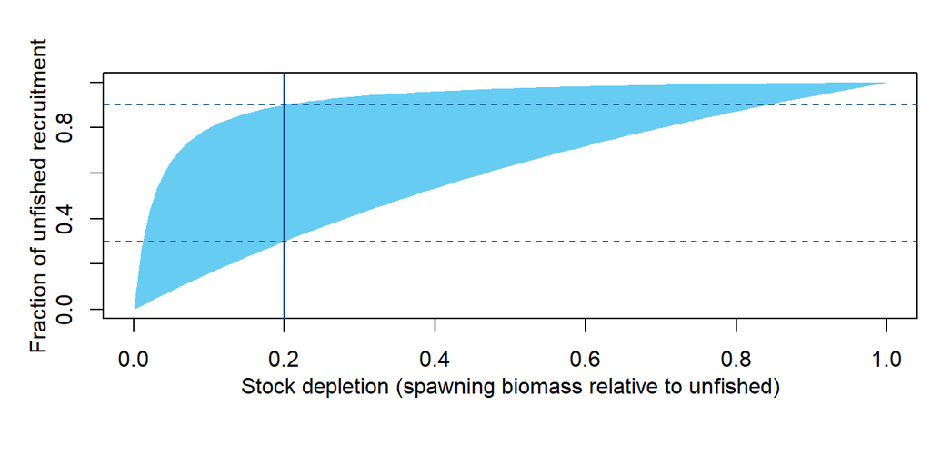

## Historical effort pattern

| Answered |
| --- |
| Stable |
| Two-phase |
| Boom-bust |
| Gradual increases |
| Stable, recent increases |
| Stable, recent declines |

| Justification |
| --- |
| Commercial licenses (found at https://www.wildlife.ca.gov/Licensing/Statistics/action/review/content/6949#commfishinglicensespermits) have bounced around 300-400 until early 2000s, where numbers stead… |

[figure not shown]

## Inter-annual variability in historical effort

| Answered |
| --- |
| Not variable (less than 20% inter-annual change (IAC)) |
| Variable (maximum IAC between 20% to 50%) |
| Highly variable (maximum IAC between 50% and 100%) |

[output not shown]

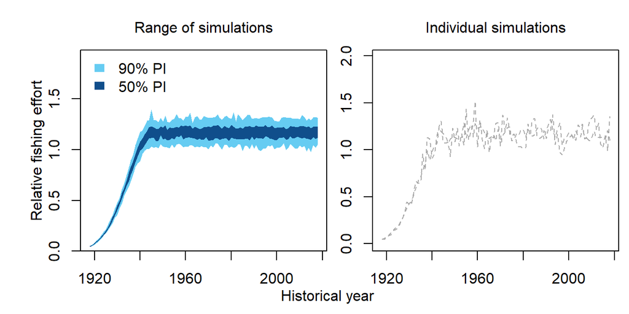

## Historical fishing efficiency changes

| Answered |
| --- |
| Declining by 2-3% pa (halves every 25-35 years) |
| Declining by 1-2% pa (halves every 35-70 years) |
| Stable -1% to 1% pa (may halve/double every 70 years) |
| Increasing by 1-2% pa (doubles every 35-70 years) |
| Increasing by 2-3% pa (doubles every 25-35 years) |

| Justification |
| --- |
| Fishing method has not changed over time and fishing areas are generally targeted in nearshore areas (no technology changes apparent). I would presume the efficiency has remained stable. |

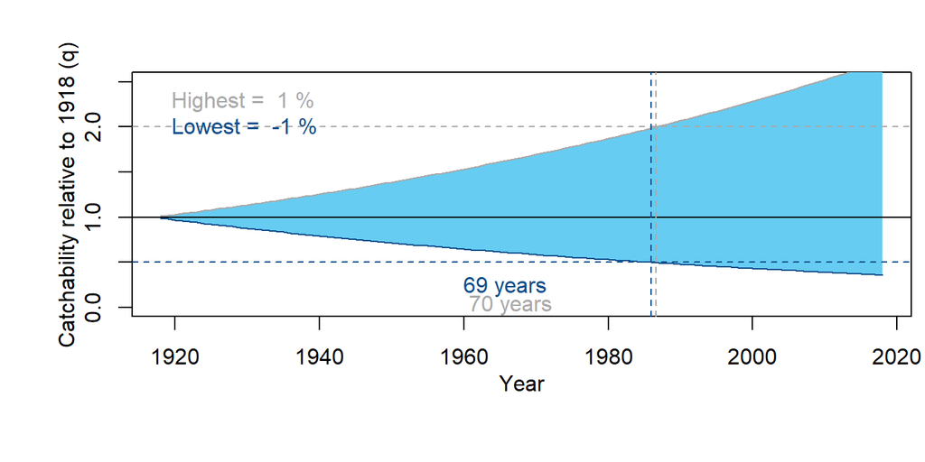